# • DOMAIN: Sports management

# • CONTEXT: Company X is a sports management company for international cricket.

# • DATA DESCRIPTION: The data is collected belongs to batsman from IPL series conducted so far. Attribute Information:

**1. Runs: Runs score by the batsman**

**2. Ave: Average runs scored by the batsman per match**

**3. SR: strike rate of the batsman**

**4. Fours: number of boundary/four scored**

**5. Six: number of boundary/six scored**

**6. HF: number of half centuries scored so far**

# • PROJECT OBJECTIVE: Goal is to build a data driven batsman ranking model for the sports management company to make business decisions.

```python
import pandas as pd
import os
import seaborn as sns
import matplotlib.pyplot as plt
import numpy as np
from scipy.stats import zscore
sns.set_style('darkgrid')
%matplotlib inline
import warnings
warnings.filterwarnings("ignore")
from sklearn.decomposition import PCA
```

```python
os.chdir('C:\\Users\\VGopalak\\Desktop\\ML\\un-supervised learning')
```

**Reading Dataset**

```python
df=pd.read_csv('Part4 - batting_bowling_ipl_bat (1).csv')
```

# Data Exploration

**Checking First 5 Rows**

```python
df.head()
```

|  | Name | Runs | Ave | SR | Fours | Sixes | HF |
| --- | --- | --- | --- | --- | --- | --- | --- |
| 0 | NaN | NaN | NaN | NaN | NaN | NaN | NaN |
| 1 | CH Gayle | 733.0 | 61.08 | 160.74 | 46.0 | 59.0 | 9.0 |
| 2 | NaN | NaN | NaN | NaN | NaN | NaN | NaN |
| 3 | G Gambhir | 590.0 | 36.87 | 143.55 | 64.0 | 17.0 | 6.0 |
| 4 | NaN | NaN | NaN | NaN | NaN | NaN | NaN |

**We can see alternate records are empty**

```python
df.shape
```

```
(180, 7)
```

```python
df.info()
```

```
<class 'pandas.core.frame.DataFrame'>
RangeIndex: 180 entries, 0 to 179
Data columns (total 7 columns):
 #   Column  Non-Null Count  Dtype
---  ------  --------------  -----
 0   Name    90 non-null     object
 1   Runs    90 non-null     float64
 2   Ave     90 non-null     float64
 3   SR      90 non-null     float64
 4   Fours   90 non-null     float64
 5   Sixes   90 non-null     float64
 6   HF      90 non-null     float64
dtypes: float64(6), object(1)
memory usage: 10.0+ KB
```

```python
df.isnull().sum()
```

```
Name     90
Runs     90
Ave      90
SR       90
Fours    90
Sixes    90
HF       90
dtype: int64
```

```python
df[df.isnull()==True]
```

|  | Name | Runs | Ave | SR | Fours | Sixes | HF |
| --- | --- | --- | --- | --- | --- | --- | --- |
| 0 | NaN | NaN | NaN | NaN | NaN | NaN | NaN |
| 1 | NaN | NaN | NaN | NaN | NaN | NaN | NaN |
| 2 | NaN | NaN | NaN | NaN | NaN | NaN | NaN |
| 3 | NaN | NaN | NaN | NaN | NaN | NaN | NaN |
| 4 | NaN | NaN | NaN | NaN | NaN | NaN | NaN |
| ... | ... | ... | ... | ... | ... | ... | ... |
| 175 | NaN | NaN | NaN | NaN | NaN | NaN | NaN |
| 176 | NaN | NaN | NaN | NaN | NaN | NaN | NaN |
| 177 | NaN | NaN | NaN | NaN | NaN | NaN | NaN |
| 178 | NaN | NaN | NaN | NaN | NaN | NaN | NaN |
| 179 | NaN | NaN | NaN | NaN | NaN | NaN | NaN |

180 rows × 7 columns

**All the alternate rows are Null. These columns does not add any values so we are removing these columns**

```python
df.dropna(inplace=True)
```

```python
df.head()
```

|  | Name | Runs | Ave | SR | Fours | Sixes | HF |
| --- | --- | --- | --- | --- | --- | --- | --- |
| 1 | CH Gayle | 733.0 | 61.08 | 160.74 | 46.0 | 59.0 | 9.0 |
| 3 | G Gambhir | 590.0 | 36.87 | 143.55 | 64.0 | 17.0 | 6.0 |
| 5 | V Sehwag | 495.0 | 33.00 | 161.23 | 57.0 | 19.0 | 5.0 |
| 7 | CL White | 479.0 | 43.54 | 149.68 | 41.0 | 20.0 | 5.0 |
| 9 | S Dhawan | 569.0 | 40.64 | 129.61 | 58.0 | 18.0 | 5.0 |

**All empty rows are dropped.**

# Data Analysis and Visualisation:

```python
df.describe()
```

|  | Runs | Ave | SR | Fours | Sixes | HF |
| --- | --- | --- | --- | --- | --- | --- |
| count | 90.000000 | 90.000000 | 90.000000 | 90.000000 | 90.000000 | 90.000000 |
| mean | 219.933333 | 24.729889 | 119.164111 | 19.788889 | 7.577778 | 1.188889 |
| std | 156.253669 | 13.619215 | 23.656547 | 16.399845 | 8.001373 | 1.688656 |
| min | 2.000000 | 0.500000 | 18.180000 | 0.000000 | 0.000000 | 0.000000 |
| 25% | 98.000000 | 14.665000 | 108.745000 | 6.250000 | 3.000000 | 0.000000 |
| 50% | 196.500000 | 24.440000 | 120.135000 | 16.000000 | 6.000000 | 0.500000 |
| 75% | 330.750000 | 32.195000 | 131.997500 | 28.000000 | 10.000000 | 2.000000 |
| max | 733.000000 | 81.330000 | 164.100000 | 73.000000 | 59.000000 | 9.000000 |

- **Runs:It has range between 2 to 733. We can see huge difference between 75% of data and maximum data.Distribution may be right skewed because mean is slightly greater than median.**
- **Average:Mean and median are equal. 75% of players has average of 32 but maximum average is 81.**
- **Strike Rate: Average strike rate is around 120. We are having extreme values as well. Mean and Median are nearly equal.**
- **Fours: We have players who scored No fours. Average fours are around 20 which is slightly higher than median.**
- **Sixes: It has similar values like Fours.**
- **Half Century: Players who have scored half century is very less.**

# **Univariate Analysis**

**Distribution and outlier analysis of numerical variables**

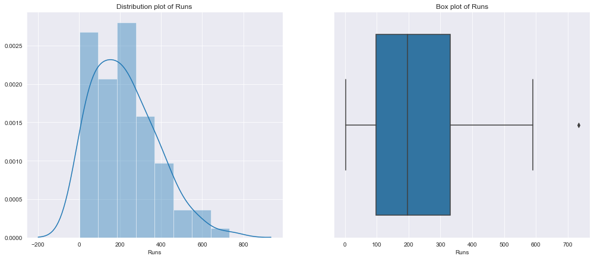

```
 Total Number of outliers in Runs: 1
```

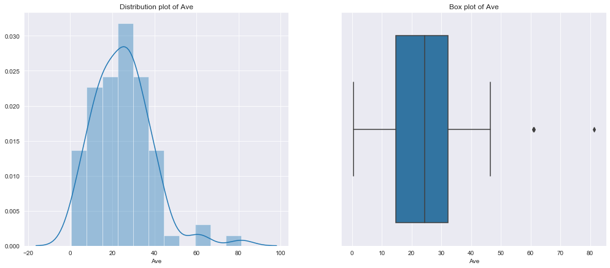

```
 Total Number of outliers in Ave: 3
```

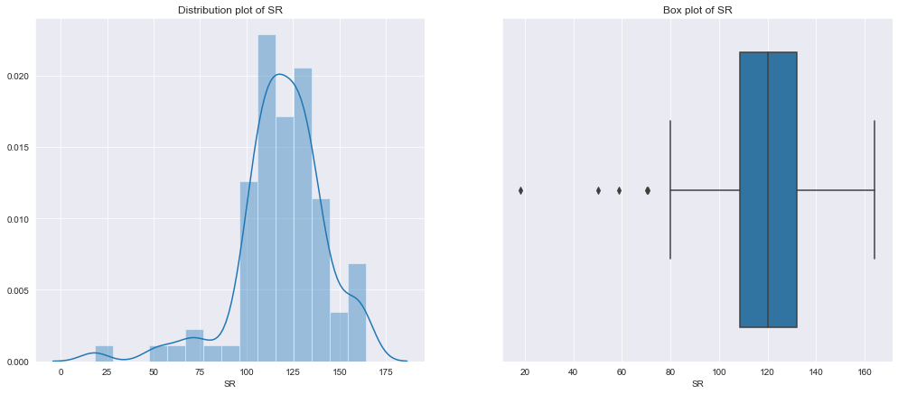

```
 Total Number of outliers in SR: 5
```

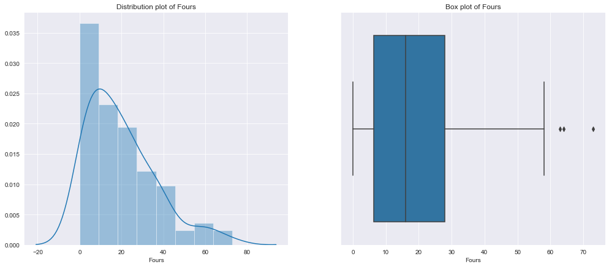

```
 Total Number of outliers in Fours: 3
```

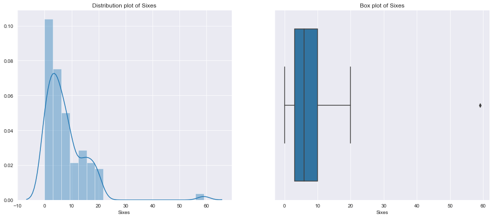

```
 Total Number of outliers in Sixes: 1
```

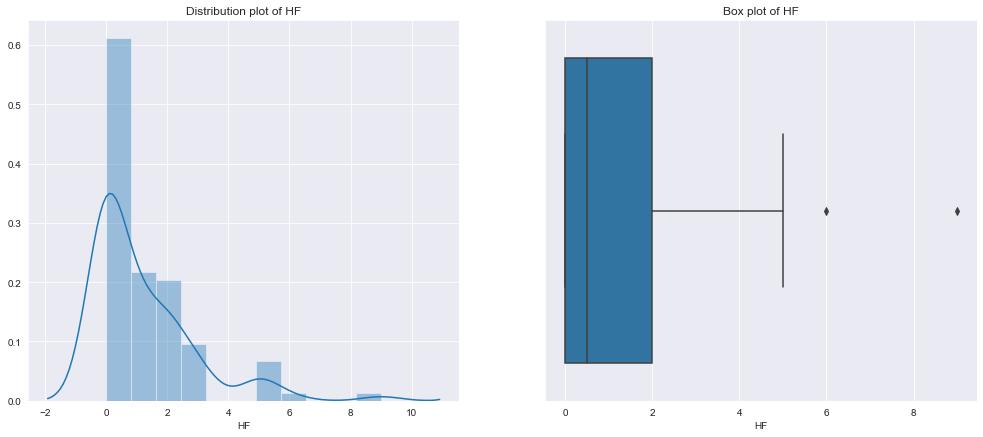

```
 Total Number of outliers in HF: 2
```

```python
for i in df.select_dtypes(include=['float64']).columns:
    f, axes = plt.subplots(1, 2, figsize=(17,7))
    sns.boxplot(x = i, data=df,  orient='h' , ax=axes[1])
    #sns.set(axis_bgcolor='k')
    sns.distplot(df[i],  ax=axes[0])
    axes[0].set_title('Distribution plot of {}'.format(i))
    axes[1].set_title('Box plot of {}'.format(i))
    plt.show()
    #checking count of outliers.
    q25,q75=np.percentile(df[i],25),np.percentile(df[i],75)
    IQR=q75-q25
    Threshold=IQR*1.5
    lower,upper=q25-Threshold,q75+Threshold
    Outliers=[i for i in df[i] if i < lower or i > upper]
    print('{} Total Number of outliers in {}: {}'.format('\033[1m',i,len(Outliers)))
```

**We have few outliers in data.**

**Pairplot**

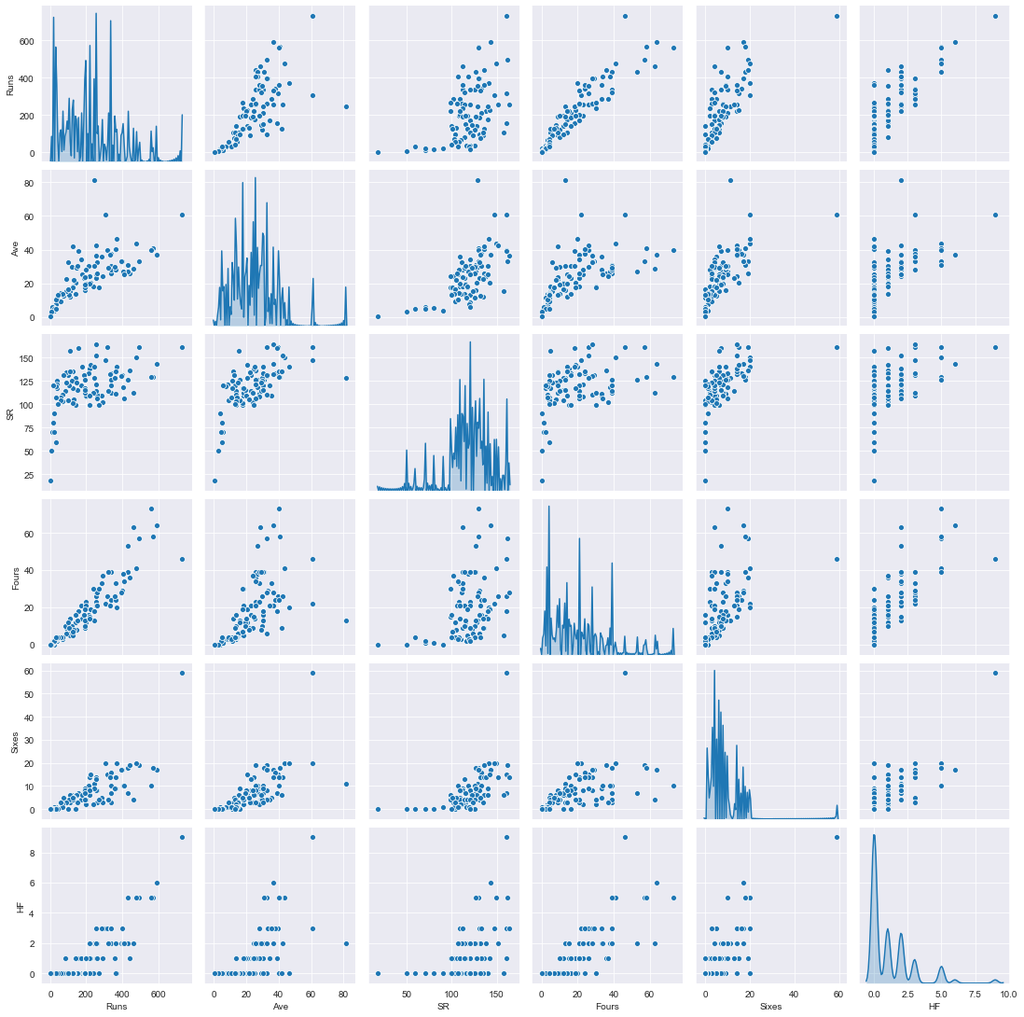

```python
sns.pairplot(df,diag_kind='kde',diag_kws={'bw': 0.2})
```

- **We can see linear relationship between Runs,Fours and average. so whenever there is increase in run there is increase in Fours and average.**
- **We can se different distributions in data. Players with no half centuries has scored large runs as well. These players may be finishers.**
- **Players with maximum half centuries have scored lot of runs. This corresponds to openers. Some of the middle order batsmens also scored few half centuries.**
- **We have players who have very less strike rate and runs. This indicates we have data for bowlers as well.**
- **Players with average between 20 to 30 has many 6's,4's and strike rate also high for them**
- **We have players whose strike rate average is 120 . Players whose strike rate is more have more number of 6's and 4's. This record may be collected from T20 Match.**
- **We have players who scored many fours but not achieved half century. They might have batted at end of the innings.**

# PCA

```python
df.shape
```

```
(90, 7)
```

```python
df.columns
```

```
Index(['Name', 'Runs', 'Ave', 'SR', 'Fours', 'Sixes', 'HF'], dtype='object')
```

```python
df.set_index('Name',inplace=True) # we are making player names as index. so while ranking we can interpret easily.
```

```python
X=df.copy()
```

```python
li=list(df.select_dtypes(include=['float64']).columns)
print(li)
```

```
['Runs', 'Ave', 'SR', 'Fours', 'Sixes', 'HF']
```

```python
X[li]=X[li].apply(zscore) #replacing each continuous values with z-score value
```

**Covariance Matrix**

```python
covMatrix = np.cov(X,rowvar=False)
print(covMatrix.shape)
```

```
(6, 6)
```

```python
covMatrix
```

```
array([[1.01123596, 0.70077082, 0.49903347, 0.9291323 , 0.77842677,
        0.84453142],
       [0.70077082, 1.01123596, 0.63061271, 0.55234856, 0.69008186,
        0.62772842],
       [0.49903347, 0.63061271, 1.01123596, 0.38913406, 0.59050396,
        0.43238784],
       [0.9291323 , 0.55234856, 0.38913406, 1.01123596, 0.52844526,
        0.79249429],
       [0.77842677, 0.69008186, 0.59050396, 0.52844526, 1.01123596,
        0.77632221],
       [0.84453142, 0.62772842, 0.43238784, 0.79249429, 0.77632221,
        1.01123596]])
```

**Creating PCA**

```python
pca = PCA(n_components=6) #we will create 6 components
pca.fit(X)
```

```
PCA(n_components=6)
```

**Eigen Values**

```python
print(pca.explained_variance_)
```

```
[4.30252561 0.83636692 0.41665751 0.32912443 0.16567829 0.01706297]
```

- **We can see variance explained by each components**
- **In PCA, First Component will explain maximum variance.**
- **These Explained variances are known as eigen values.**

**Eigen Vectors**

```python
print(pca.components_)
```

```
[[ 0.4582608   0.39797313  0.3253838   0.40574167  0.41733459  0.43237178]
 [ 0.26643209 -0.33111756 -0.69780334  0.47355804 -0.17902455  0.27593225]
 [-0.10977942  0.00550486 -0.45013448 -0.50823538  0.66942589  0.28082541]
 [-0.00520142  0.84736307 -0.43275029 -0.03252305 -0.24878157 -0.17811777]
 [ 0.45840889 -0.10122837 -0.11890348  0.09676885  0.39458014 -0.77486668]
 [ 0.70483594 -0.0606373   0.05624934 -0.58514214 -0.35786211  0.16096217]]
```

- **These are array of principle components. Since we have built 6 pricipal components we have 6 rows.**
- **Each column explains how much each principal components is covered the particular feature i.e Each column explaines weightage of each feature in each components.**
- **We will make use of these weightage values to rank each row of the dataset.**
- **We will use weightage values from first priciple components because it explains maximum variance in the data.**

```python
print((pca.components_.shape))
```

```
(6, 6)
```

**Explained Variance Ratio**

```python
print(pca.explained_variance_ratio_)
```

```
[0.70911996 0.13784566 0.06867133 0.05424458 0.02730624 0.00281223]
```

```
[0.70911996 0.84696562 0.91563695 0.96988153 0.99718777 1.        ]
```

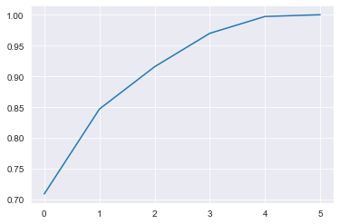

```python
plt.plot(np.cumsum(pca.explained_variance_ratio_))
print(np.cumsum(pca.explained_variance_ratio_))
```

```python
weightage=list(pca.components_[0])
```

```python
weightage
```

```
[0.45826079698487576,
 0.39797313390952777,
 0.32538379579240184,
 0.4057416698518075,
 0.417334586688651,
 0.4323717754063333]
```

- **We will multiply these weightagevalues with all feature values and summation of that will give rank of particular player.**
- **For example:0.45*Runs+0.39*Average+0.32*Strike+0.40*Four+0.41*Six+0.43*HF**

```python
rank=[]
for i in range(0,len(X)):
    s=[]
    for j,k in zip(X.values[i],weightage):
        #print(j*k)
        s.append(j*k)
    rank.append(sum(s))
```

```python
df['Score']=rank #creating column in original dataframe which has non-scale value(i.e original value)
```

**We can see score is assigned to each player. Based on the score value we will assign rank to each player.**

```python
df['Ranking'] =df['Score'].rank(method='dense', ascending=False)
```

```python
df.sort_values(by='Ranking')
```

| Name | Runs | Ave | SR | Fours | Sixes | HF | Score | Ranking |
| --- | --- | --- | --- | --- | --- | --- | --- | --- |
| CH Gayle | 733.0 | 61.08 | 160.74 | 46.0 | 59.0 | 9.0 | 8.516774 | 1.0 |
| G Gambhir | 590.0 | 36.87 | 143.55 | 64.0 | 17.0 | 6.0 | 4.618340 | 2.0 |
| V Sehwag | 495.0 | 33.00 | 161.23 | 57.0 | 19.0 | 5.0 | 4.142251 | 3.0 |
| S Dhawan | 569.0 | 40.64 | 129.61 | 58.0 | 18.0 | 5.0 | 4.120072 | 4.0 |
| AM Rahane | 560.0 | 40.00 | 129.33 | 73.0 | 10.0 | 5.0 | 4.024436 | 5.0 |
| ... | ... | ... | ... | ... | ... | ... | ... | ... |
| WD Parnell | 19.0 | 4.75 | 70.37 | 2.0 | 0.0 | 0.0 | -3.000751 | 86.0 |
| Z Khan | 12.0 | 6.00 | 70.58 | 1.0 | 0.0 | 0.0 | -3.006639 | 87.0 |
| PC Valthaty | 30.0 | 5.00 | 58.82 | 4.0 | 0.0 | 0.0 | -3.070959 | 88.0 |
| RP Singh | 6.0 | 3.00 | 50.00 | 0.0 | 0.0 | 0.0 | -3.422022 | 89.0 |
| R Sharma | 2.0 | 0.50 | 18.18 | 0.0 | 0.0 | 0.0 | -3.947402 | 90.0 |

90 rows × 8 columns

**Gayle is the most valuable player**

**We have ranked all the players using PCA.**

**This helps sports management company to make business decisons.**